# Hands-on session: GRANAR – Generator of root anatomies in R

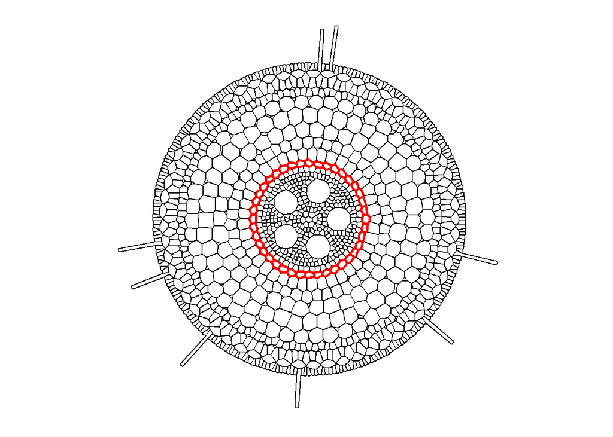

```r
plot_anatomy(sim_complx, col = "segment", apo_bar = 2)
```

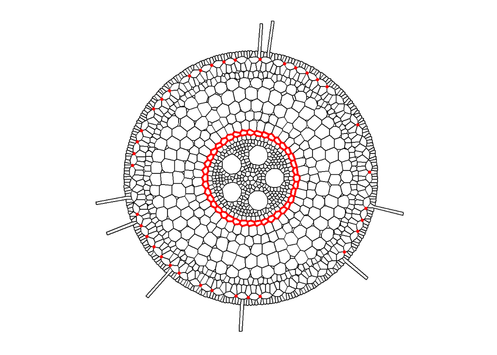

```r
plot_anatomy(sim_complx, col = "segment", apo_bar = 3)
```

GRANAR is aslo able to run secondary growth pattern.

```r
params_complx <- read_param_xml(path = "./www/root_dicot_secGrowth.xml")
sim_complx = create_anatomy(parameters = params_complx)
```

```
## 1/2
```

```
## 2/2
```

```
## Time difference of 12.75345 secs
```

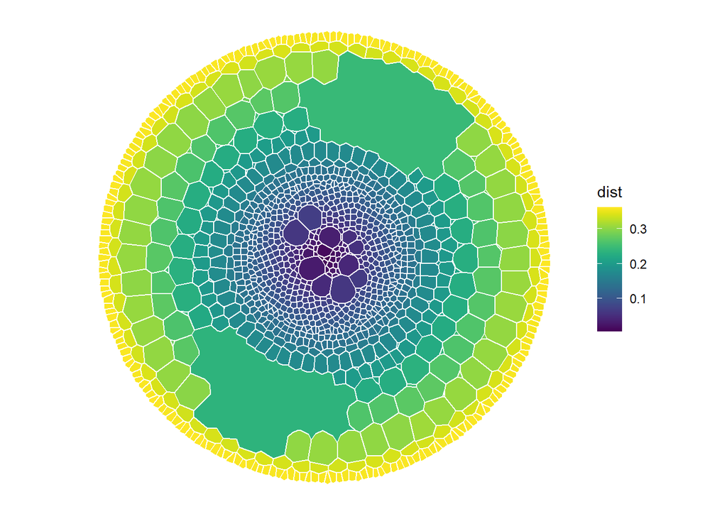

```r
# To visualize the anatomy and the scenario that are going to be tested.
# you can use the plot_anatomy function.

plot_anatomy(sim_complx, col = "dist")
```

## Make your own!

```r
# Change the parameter directly in the .xml or with multiple
# my_params$value[my_params$type == "" & my_params$name == ""] =
my_params <- read_param_xml(path = "./www/root_monocot_simpl.xml") # "./www/my_root.xml"
my_sim = create_anatomy(parameters = my_params)
```

```
## Increasing madj from 124 to 149 and trying again.
```

```
## Time difference of 3.320206 secs
```

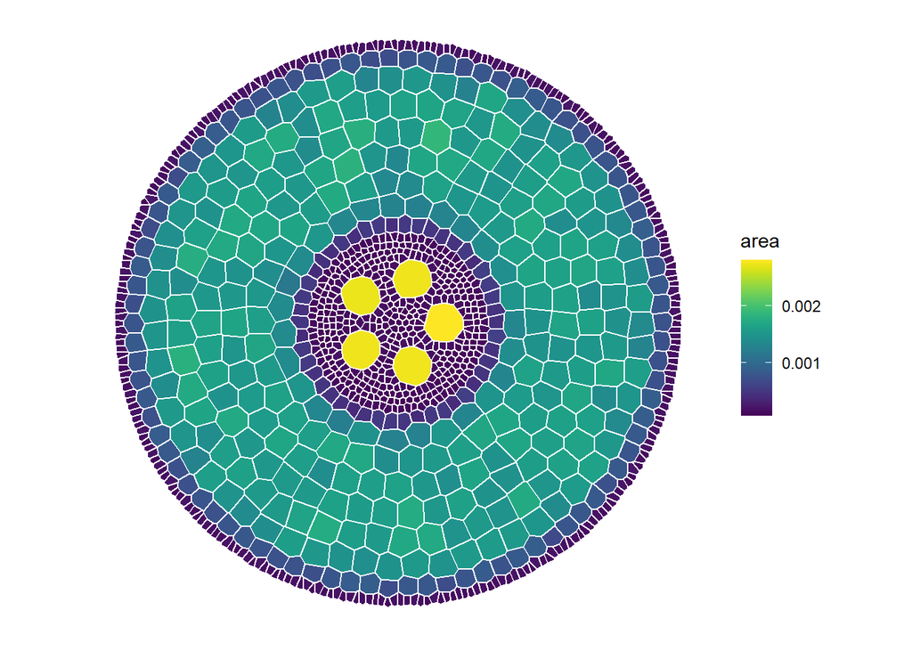

```r
plot_anatomy(my_sim, col = "area")
```

```r
write_anatomy_xml(my_sim, "../MECHA/cellsetdata/test_root.xml")
```

```
##    id_group                 type
## 1         1            exodermis
## 2         2            epidermis
## 3         3           endodermis
## 4         3         passage_cell
## 5         4               cortex
## 6         5                stele
## 7        13                xylem
## 8        16            pericycle
## 9        12       companion_cell
## 10       11               phloem
## 11        4 inter_cellular_space
## 12        4           aerenchyma
## 13       11              cambium
## 14       13            metaxylem
```

```
## [1] TRUE
```

```r
aer_in_geom_xml(my_sim, "../MECHA/Projects/granar/in/Maize_Geometry.xml")
```

```
## no aerenchyma
```

```
## [1] TRUE
```

```r
file.copy("../MECHA/Projects/granar/in/Maize_Geometry_aer.xml",
          "../MECHA/Projects/granar/in/Maize_Geometry_aer_test.xml" , overwrite = T)
```

```
## [1] TRUE
```

## Comparing root types

Different root types can be generated from their respective parameter sets. Here we compare lateral, seminal, and nodal roots of a maize plant.

```r
# load the parameter sets
params_lat <- read_param_xml(path = "./www/lateral_root.xml")
params_sem <- read_param_xml(path = "./www/seminal_root.xml")
params_nod <- read_param_xml(path = "./www/nodal_root.xml")

# generation of the anatomies
sim_lat = create_anatomy(parameters = params_lat)
```

```
## Time difference of 0.70839 secs
```

```r
sim_sem = create_anatomy(parameters = params_sem)
```

```
## Increasing madj from 112 to 135 and trying again.
```

```
## Time difference of 2.2357 secs
```

```r
sim_nod = create_anatomy(parameters = params_nod)
```

```
## 1/6
```

```
## 2/6
```

```
## 3/6
```

```
## 4/6
```

```
## 5/6
```

```
## 6/6
```

```
## Time difference of 9.127267 secs
```

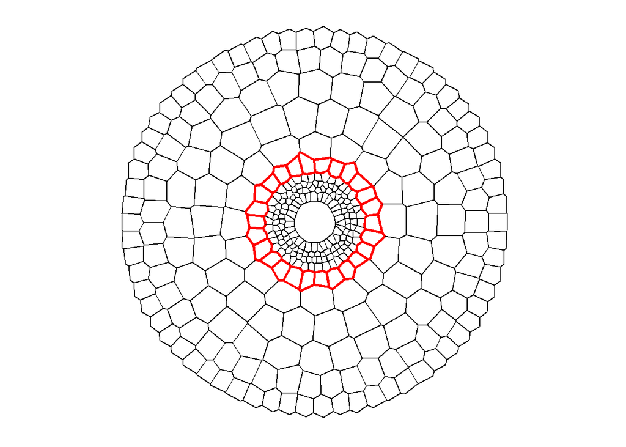

```r
# check of the anatomies
plot_anatomy(sim_lat, col = "segment", apo_bar = 2)
```

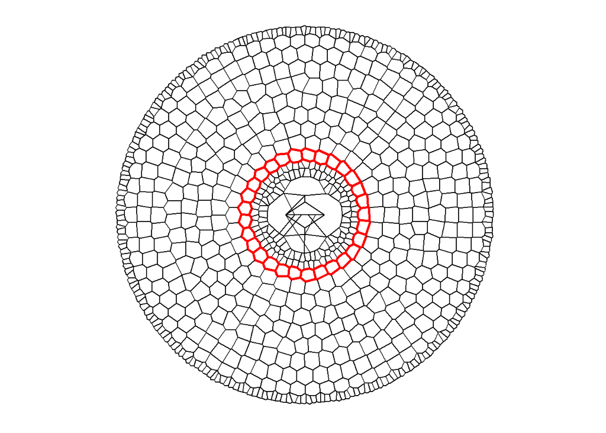

```r
plot_anatomy(sim_sem, col = "segment", apo_bar = 2)
```

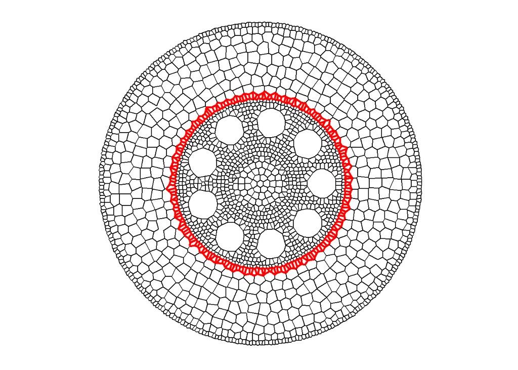

```r
plot_anatomy(sim_nod, col = "segment", apo_bar = 2)
```

## Exporting data for other functional models

The simulated anatomies can be saved in XML format for later use with MECHA. We will export both cell set data and geometrical information (with aerenchyma).

```r
# save the nodes data
write_anatomy_xml(sim_lat, "../MECHA/cellsetdata/root_lat.xml")
```

```
##    id_group                 type
## 1         1            exodermis
## 2         2            epidermis
## 3         3           endodermis
## 4         3         passage_cell
## 5         4               cortex
## 6         5                stele
## 7        13                xylem
## 8        16            pericycle
## 9        12       companion_cell
## 10       11               phloem
## 11        4 inter_cellular_space
## 12        4           aerenchyma
## 13       11              cambium
## 14       13            metaxylem
```

```
## [1] TRUE
```

```r
write_anatomy_xml(sim_sem, "../MECHA/cellsetdata/root_sem.xml")
```

```
##    id_group                 type
## 1         1            exodermis
## 2         2            epidermis
## 3         3           endodermis
## 4         3         passage_cell
## 5         4               cortex
## 6         5                stele
## 7        13                xylem
## 8        16            pericycle
## 9        12       companion_cell
## 10       11               phloem
## 11        4 inter_cellular_space
## 12        4           aerenchyma
## 13       11              cambium
## 14       13            metaxylem
```

```
## [1] TRUE
```

```r
write_anatomy_xml(sim_nod, "../MECHA/cellsetdata/root_nod.xml")
```

```
##    id_group                 type
## 1         1            exodermis
## 2         2            epidermis
## 3         3           endodermis
## 4         3         passage_cell
## 5         4               cortex
## 6         5                stele
## 7        13                xylem
## 8        16            pericycle
## 9        12       companion_cell
## 10       11               phloem
## 11        4 inter_cellular_space
## 12        4           aerenchyma
## 13       11              cambium
## 14       13            metaxylem
```

```
## [1] TRUE
```

```r
# save the geometrical information - aerenchyma
aer_in_geom_xml(sim_lat, "../MECHA/Projects/granar/in/Maize_Geometry.xml")
```

```
## no aerenchyma
```

```
## [1] TRUE
```

```r
file.copy("../MECHA/Projects/granar/in/Maize_Geometry_aer.xml",
          "../MECHA/Projects/granar/in/Maize_Geometry_aer_lat.xml" , overwrite = T)
```

```
## [1] TRUE
```

```r
aer_in_geom_xml(sim_sem, "../MECHA/Projects/granar/in/Maize_Geometry.xml")
```

```
## no aerenchyma
```

```
## [1] TRUE
```

```r
file.copy("../MECHA/Projects/granar/in/Maize_Geometry_aer.xml",
          "../MECHA/Projects/granar/in/Maize_Geometry_aer_sem.xml" , overwrite = T)
```

```
## [1] TRUE
```

```r
aer_in_geom_xml(sim_nod, "../MECHA/Projects/granar/in/Maize_Geometry.xml")
```

```
## [1] TRUE
```

```r
file.copy("../MECHA/Projects/granar/in/Maize_Geometry_aer.xml",
          "../MECHA/Projects/granar/in/Maize_Geometry_aer_nod.xml" , overwrite = T)
```

```
## [1] TRUE
```

## recap:

- You learned how to load and modify parameter files in GRANAR
- You generated and visualized different root anatomies
- You explored anatomical complexity with apoplastic barriers
- You exported anatomies for further simulations with MECHA